# Project_Anil_Bank_Churn_Prediction

## Bank Churn Prediction

### Objective:

Given a Bank customer, build a neural network based classifier that can determine whether they will leave or not in the next 6 months.

### Context:

Businesses like banks which provide service have to worry about problem of 'Churn' i.e. customers leaving and joining another service provider. It is important to understand which aspects of the service influence a customer's decision in this regard. Management can concentrate efforts on improvement of service, keeping in mind these priorities.

### Dataset

The dataset contains 10,000 sample points with 14 distinct features such as CustomerId, CreditScore, Geography, Gender, Age, Tenure, Balance etc.

### Sub-Tasks of this project

1. Read the dataset
2. Drop the columns which are unique for all users like IDs
3. Distinguish the features and target variable
4. Divide the data set into training and test sets
5. Normalize the train and test data
6. Initialize & build the model. Identify the points of improvement and implement the same the same.
7. Predict the results using 0.5 as a threshold
8. Print the Accuracy score and confusion matrix

```python
import tensorflow as tf
print(tf.__version__)
```

```
2.3.0
```

```python
import pandas as pd
import pandas_profiling as pf
import numpy as np
from sklearn.model_selection import train_test_split
import tensorflow as tf
from sklearn import preprocessing
from tensorflow.keras.models import Sequential
from tensorflow.keras.layers import Dense, Dropout, BatchNormalization
from sklearn.metrics import accuracy_score, confusion_matrix, precision_score, recall_score, f1_score, precision_recall_curve, auc
import matplotlib.pyplot as plt
from tensorflow.keras import optimizers

from IPython.display import Markdown, display
import seaborn as sns # data visualization lib based upon matplotlib
import matplotlib.pyplot as plt # is a state-based interface to matplotlib. It provides a MATLAB-like way of plotting
%matplotlib inline
```

### 1. Read the dataset

```python
data = pd.read_csv('bank.csv')
```

```python
data.shape
```

```
(10000, 14)
```

### 2. Drop the columns which are unique for all users like IDs

```python
data.head(10)
```

|  | RowNumber | CustomerId | Surname | CreditScore | Geography | Gender | Age | Tenure | Balance | NumOfProducts | HasCrCard | IsActiveMember | EstimatedSalary | Exited |
| --- | --- | --- | --- | --- | --- | --- | --- | --- | --- | --- | --- | --- | --- | --- |
| 0 | 1 | 15634602 | Hargrave | 619 | France | Female | 42 | 2 | 0.00 | 1 | 1 | 1 | 101348.88 | 1 |
| 1 | 2 | 15647311 | Hill | 608 | Spain | Female | 41 | 1 | 83807.86 | 1 | 0 | 1 | 112542.58 | 0 |
| 2 | 3 | 15619304 | Onio | 502 | France | Female | 42 | 8 | 159660.80 | 3 | 1 | 0 | 113931.57 | 1 |
| 3 | 4 | 15701354 | Boni | 699 | France | Female | 39 | 1 | 0.00 | 2 | 0 | 0 | 93826.63 | 0 |
| 4 | 5 | 15737888 | Mitchell | 850 | Spain | Female | 43 | 2 | 125510.82 | 1 | 1 | 1 | 79084.10 | 0 |
| 5 | 6 | 15574012 | Chu | 645 | Spain | Male | 44 | 8 | 113755.78 | 2 | 1 | 0 | 149756.71 | 1 |
| 6 | 7 | 15592531 | Bartlett | 822 | France | Male | 50 | 7 | 0.00 | 2 | 1 | 1 | 10062.80 | 0 |
| 7 | 8 | 15656148 | Obinna | 376 | Germany | Female | 29 | 4 | 115046.74 | 4 | 1 | 0 | 119346.88 | 1 |
| 8 | 9 | 15792365 | He | 501 | France | Male | 44 | 4 | 142051.07 | 2 | 0 | 1 | 74940.50 | 0 |
| 9 | 10 | 15592389 | H? | 684 | France | Male | 27 | 2 | 134603.88 | 1 | 1 | 1 | 71725.73 | 0 |

Let's drop RowNumber, CustomerId, Surname they are not useful of predictive analysis

```python
data.drop(['RowNumber', 'CustomerId', 'Surname'], axis=1, inplace= True)
```

### 3. Distinguish the features and target variable

We'll check data info, null, na values

```python
data.info()
```

```
<class 'pandas.core.frame.DataFrame'>
RangeIndex: 10000 entries, 0 to 9999
Data columns (total 11 columns):
 #   Column           Non-Null Count  Dtype
---  ------           --------------  -----
 0   CreditScore      10000 non-null  int64
 1   Geography        10000 non-null  object
 2   Gender           10000 non-null  object
 3   Age              10000 non-null  int64
 4   Tenure           10000 non-null  int64
 5   Balance          10000 non-null  float64
 6   NumOfProducts    10000 non-null  int64
 7   HasCrCard        10000 non-null  int64
 8   IsActiveMember   10000 non-null  int64
 9   EstimatedSalary  10000 non-null  float64
 10  Exited           10000 non-null  int64
dtypes: float64(2), int64(7), object(2)
memory usage: 859.5+ KB
```

```python
# method to check null/na values
def print_null_na_values(data):
    print("Are there any null values ? : ", data.isnull().values.any())
    print("Are there any na values ?   : ", data.isna().values.any())

    print("\n")
    print("------------Checking for null ------------------")
    print(data.isnull().sum())
    print("------------Cheking for NA ---------------------")
    print(data.isna().sum())
```

```python
print_null_na_values(data)
```

```
Are there any null values ? :  False
Are there any na values ?   :  False


------------Checking for null ------------------
CreditScore        0
Geography          0
Gender             0
Age                0
Tenure             0
Balance            0
NumOfProducts      0
HasCrCard          0
IsActiveMember     0
EstimatedSalary    0
Exited             0
dtype: int64
------------Cheking for NA ---------------------
CreditScore        0
Geography          0
Gender             0
Age                0
Tenure             0
Balance            0
NumOfProducts      0
HasCrCard          0
IsActiveMember     0
EstimatedSalary    0
Exited             0
dtype: int64
```

```python
# method to get unique values for all columns
def uniques_values(data):
    for col in data.columns:
        print('Col Name {0}: Unique values {1}'.format(col, data[col].nunique()))
```

```python
uniques_values(data)
```

```
Col Name CreditScore: Unique values 460
Col Name Geography: Unique values 3
Col Name Gender: Unique values 2
Col Name Age: Unique values 70
Col Name Tenure: Unique values 11
Col Name Balance: Unique values 6382
Col Name NumOfProducts: Unique values 4
Col Name HasCrCard: Unique values 2
Col Name IsActiveMember: Unique values 2
Col Name EstimatedSalary: Unique values 9999
Col Name Exited: Unique values 2
```

- There are no null/na values
- Following features should be converted as category - Geography, Gender
- 'Existed' seems to be our target vairable

```python
cat_features = ['Geography', 'Gender']

for colname in cat_features:
    data[colname] = data[colname].astype('category')
```

```python
data[cat_features].nunique()
```

```
Geography    3
Gender       2
dtype: int64
```

```python
dfHEncoded_1 = pd.get_dummies(data)
```

```python
dfHEncoded_1.info()
```

```
<class 'pandas.core.frame.DataFrame'>
RangeIndex: 10000 entries, 0 to 9999
Data columns (total 14 columns):
 #   Column             Non-Null Count  Dtype
---  ------             --------------  -----
 0   CreditScore        10000 non-null  int64
 1   Age                10000 non-null  int64
 2   Tenure             10000 non-null  int64
 3   Balance            10000 non-null  float64
 4   NumOfProducts      10000 non-null  int64
 5   HasCrCard          10000 non-null  int64
 6   IsActiveMember     10000 non-null  int64
 7   EstimatedSalary    10000 non-null  float64
 8   Exited             10000 non-null  int64
 9   Geography_France   10000 non-null  uint8
 10  Geography_Germany  10000 non-null  uint8
 11  Geography_Spain    10000 non-null  uint8
 12  Gender_Female      10000 non-null  uint8
 13  Gender_Male        10000 non-null  uint8
dtypes: float64(2), int64(7), uint8(5)
memory usage: 752.1 KB
```

```python
dfHEncoded_1.head(10)
```

|  | CreditScore | Age | Tenure | Balance | NumOfProducts | HasCrCard | IsActiveMember | EstimatedSalary | Exited | Geography_France | Geography_Germany | Geography_Spain | Gender_Female | Gender_Male |
| --- | --- | --- | --- | --- | --- | --- | --- | --- | --- | --- | --- | --- | --- | --- |
| 0 | 619 | 42 | 2 | 0.00 | 1 | 1 | 1 | 101348.88 | 1 | 1 | 0 | 0 | 1 | 0 |
| 1 | 608 | 41 | 1 | 83807.86 | 1 | 0 | 1 | 112542.58 | 0 | 0 | 0 | 1 | 1 | 0 |
| 2 | 502 | 42 | 8 | 159660.80 | 3 | 1 | 0 | 113931.57 | 1 | 1 | 0 | 0 | 1 | 0 |
| 3 | 699 | 39 | 1 | 0.00 | 2 | 0 | 0 | 93826.63 | 0 | 1 | 0 | 0 | 1 | 0 |
| 4 | 850 | 43 | 2 | 125510.82 | 1 | 1 | 1 | 79084.10 | 0 | 0 | 0 | 1 | 1 | 0 |
| 5 | 645 | 44 | 8 | 113755.78 | 2 | 1 | 0 | 149756.71 | 1 | 0 | 0 | 1 | 0 | 1 |
| 6 | 822 | 50 | 7 | 0.00 | 2 | 1 | 1 | 10062.80 | 0 | 1 | 0 | 0 | 0 | 1 |
| 7 | 376 | 29 | 4 | 115046.74 | 4 | 1 | 0 | 119346.88 | 1 | 0 | 1 | 0 | 1 | 0 |
| 8 | 501 | 44 | 4 | 142051.07 | 2 | 0 | 1 | 74940.50 | 0 | 1 | 0 | 0 | 0 | 1 |
| 9 | 684 | 27 | 2 | 134603.88 | 1 | 1 | 1 | 71725.73 | 0 | 1 | 0 | 0 | 0 | 1 |

```python
# plot histogram
def plot_hist(data):
    plt.figure()
    data.hist(bins=20, figsize=(25,15), color='g', )
    plt.show()
```

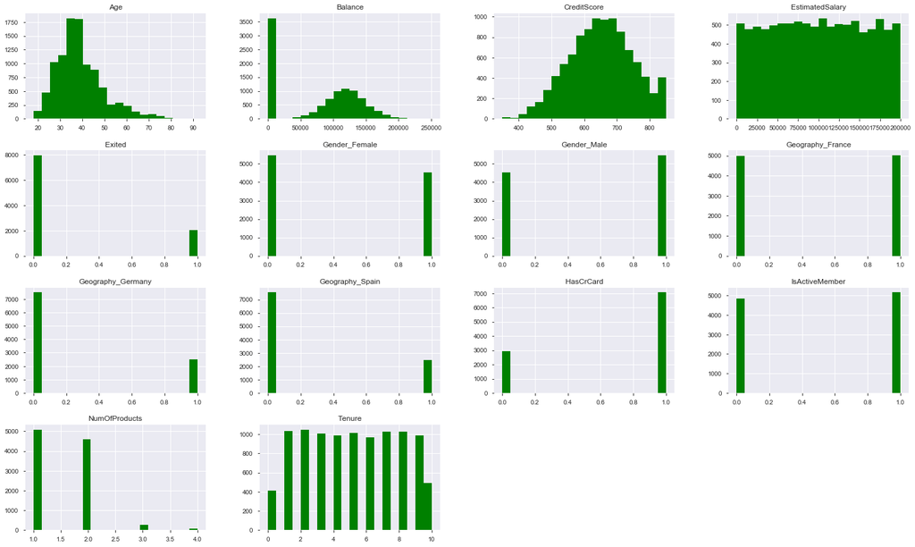

```python
plot_hist(dfHEncoded_1)
```

```python
def plot_correlation(data):
    plt.figure(figsize = (15,15))

    corr = data.corr()

    # Generate a mask for the upper triangle
    mask = np.triu(np.ones_like(corr, dtype=np.bool))

    sns.heatmap(corr, mask=mask, vmax=.3, center=0, annot=True,
            square=True, linewidths=.5, cbar_kws={"shrink": .5});
```

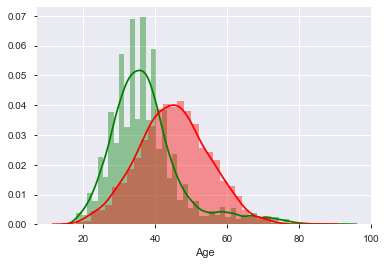

```python
sns.distplot(dfHEncoded_1['Age'][dfHEncoded_1['Exited']==0],color='green',label='non-exited')
sns.distplot(dfHEncoded_1['Age'][dfHEncoded_1['Exited']==1],color='red',label='exited')
plt.show()
```

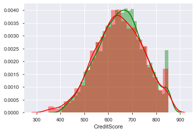

```python
sns.distplot(dfHEncoded_1['CreditScore'][dfHEncoded_1['Exited']==0],color='green',label='non-exited')
sns.distplot(dfHEncoded_1['CreditScore'][dfHEncoded_1['Exited']==1],color='red',label='exited')
plt.show()
```

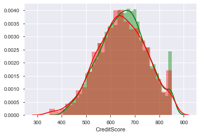

```python
sns.distplot(dfHEncoded_1['CreditScore'][dfHEncoded_1['Exited']==0],color='green',label='non-exited')
sns.distplot(dfHEncoded_1['CreditScore'][dfHEncoded_1['Exited']==1],color='red',label='exited')
plt.show()
```

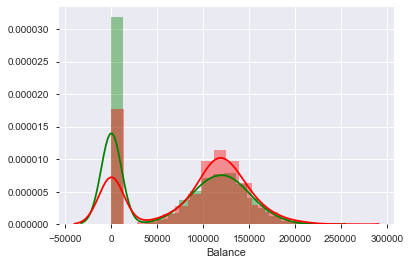

```python
sns.distplot(dfHEncoded_1['Balance'][dfHEncoded_1['Exited']==0],color='green',label='non-exited')
sns.distplot(dfHEncoded_1['Balance'][dfHEncoded_1['Exited']==1],color='red',label='exited')
plt.show()
```

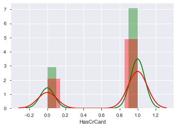

```python
sns.distplot(dfHEncoded_1['HasCrCard'][dfHEncoded_1['Exited']==0],color='green',label='non-exited')
sns.distplot(dfHEncoded_1['HasCrCard'][dfHEncoded_1['Exited']==1],color='red',label='exited')
plt.show()
```

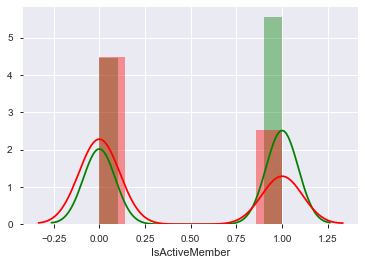

```python
sns.distplot(dfHEncoded_1['IsActiveMember'][dfHEncoded_1['Exited']==0],color='green',label='non-exited')
sns.distplot(dfHEncoded_1['IsActiveMember'][dfHEncoded_1['Exited']==1],color='red',label='exited')
plt.show()
```

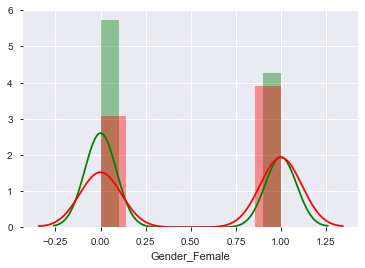

```python
sns.distplot(dfHEncoded_1['Gender_Female'][dfHEncoded_1['Exited']==0],color='green',label='non-exited')
sns.distplot(dfHEncoded_1['Gender_Female'][dfHEncoded_1['Exited']==1],color='red',label='exited')
plt.show()
```

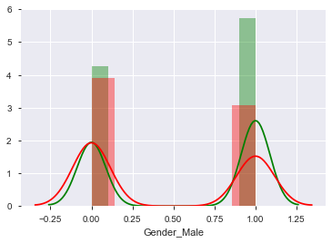

```python
sns.distplot(dfHEncoded_1['Gender_Male'][dfHEncoded_1['Exited']==0],color='green',label='non-exited')
sns.distplot(dfHEncoded_1['Gender_Male'][dfHEncoded_1['Exited']==1],color='red',label='exited')
plt.show()
```

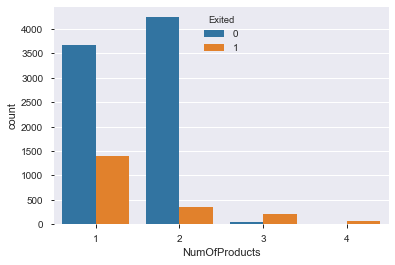

```python
sns.countplot(x='NumOfProducts', hue='Exited', data=dfHEncoded_1)
```

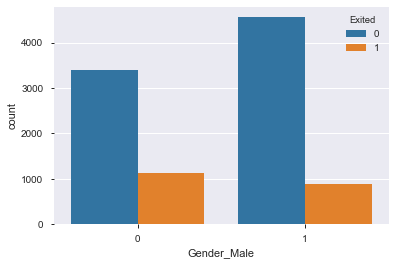

```python
sns.countplot(x='Gender_Male', hue='Exited', data=dfHEncoded_1)
```

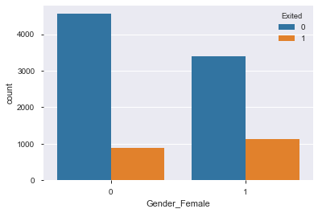

```python
sns.countplot(x='Gender_Female', hue='Exited', data=dfHEncoded_1)
```

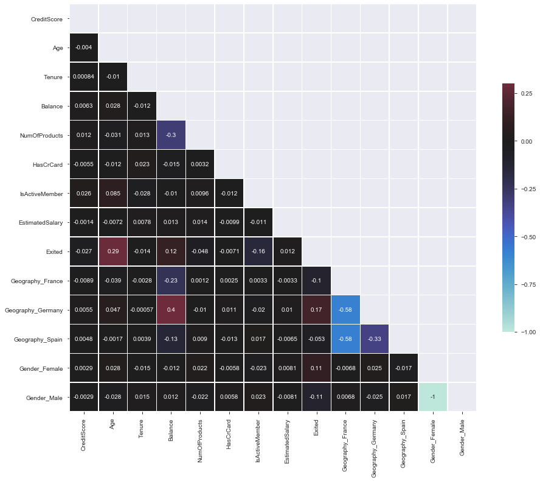

```python
plot_correlation(dfHEncoded_1)
```

### 4. Divide the data set into training and test sets

```python
X = dfHEncoded_1.drop(['Exited'], axis = 1)
y = dfHEncoded_1['Exited']
```

```python
X.info()
```

```
<class 'pandas.core.frame.DataFrame'>
RangeIndex: 10000 entries, 0 to 9999
Data columns (total 13 columns):
 #   Column             Non-Null Count  Dtype
---  ------             --------------  -----
 0   CreditScore        10000 non-null  int64
 1   Age                10000 non-null  int64
 2   Tenure             10000 non-null  int64
 3   Balance            10000 non-null  float64
 4   NumOfProducts      10000 non-null  int64
 5   HasCrCard          10000 non-null  int64
 6   IsActiveMember     10000 non-null  int64
 7   EstimatedSalary    10000 non-null  float64
 8   Geography_France   10000 non-null  uint8
 9   Geography_Germany  10000 non-null  uint8
 10  Geography_Spain    10000 non-null  uint8
 11  Gender_Female      10000 non-null  uint8
 12  Gender_Male        10000 non-null  uint8
dtypes: float64(2), int64(6), uint8(5)
memory usage: 674.0 KB
```

```python
X.head()
```

|  | CreditScore | Age | Tenure | Balance | NumOfProducts | HasCrCard | IsActiveMember | EstimatedSalary | Geography_France | Geography_Germany | Geography_Spain | Gender_Female | Gender_Male |
| --- | --- | --- | --- | --- | --- | --- | --- | --- | --- | --- | --- | --- | --- |
| 0 | 619 | 42 | 2 | 0.00 | 1 | 1 | 1 | 101348.88 | 1 | 0 | 0 | 1 | 0 |
| 1 | 608 | 41 | 1 | 83807.86 | 1 | 0 | 1 | 112542.58 | 0 | 0 | 1 | 1 | 0 |
| 2 | 502 | 42 | 8 | 159660.80 | 3 | 1 | 0 | 113931.57 | 1 | 0 | 0 | 1 | 0 |
| 3 | 699 | 39 | 1 | 0.00 | 2 | 0 | 0 | 93826.63 | 1 | 0 | 0 | 1 | 0 |
| 4 | 850 | 43 | 2 | 125510.82 | 1 | 1 | 1 | 79084.10 | 0 | 0 | 1 | 1 | 0 |

```python
#test train split
test_size = 0.30 # taking 70:30 training and test set
seed = 7  # Random numbmer seeding for reapeatability of the code
X_train, X_test, y_train, y_test = train_test_split(X, y, test_size=test_size, random_state=seed)
```

```python
#hCheck Shape of test/trainset
X_train.shape, X_test.shape, y_train.shape, y_test.shape
```

```
((7000, 13), (3000, 13), (7000,), (3000,))
```

### 5. Normalize the train and test data

```python
from sklearn.preprocessing import StandardScaler # Z-scores

# Define the scaler
scaler = StandardScaler().fit(X_train)

# Scale the train set
X_train = scaler.transform(X_train)

# Scale the test set
X_test = scaler.transform(X_test)
```

### 6.Initialize & build the model. Identify the points of improvement and implement the same the same.

```python
# Using Tensorflow Keras instead of the original Keras

from tensorflow.keras import Sequential
from tensorflow.keras.layers import Dense


ncols = X_train.shape[0]

# Initialize the constructor
model = Sequential()

# Add an first hidden layer
model.add(Dense(20, activation='relu', kernel_initializer='normal'))

# second hidden layer
model.add(Dense(10, activation='relu', kernel_initializer='normal'))


# Add an output layer with one neuron and no activation specified
model.add(Dense(1))
```

```python
#sgd = optimizers.Adam(lr = 0.001)
#model.compile(optimizer = sgd, loss = 'binary_crossentropy', metrics=['accuracy'])
optimizer = tf.keras.optimizers.Adam(0.01) # learning rate = 0.01

model.compile(loss='binary_crossentropy',
              optimizer=optimizer , metrics = ['mae' , 'mse'])


# epochs = 500
epochs = 50
```

```python
model.fit(X_train, y_train, epochs=epochs, validation_split = 0.2, verbose = False)
```

```
<tensorflow.python.keras.callbacks.History at 0x7fdeceda76d0>
```

```python
model.summary()
```

```
Model: "sequential_5"
_________________________________________________________________
Layer (type)                 Output Shape              Param #
=================================================================
dense_12 (Dense)             (None, 20)                280
_________________________________________________________________
dense_13 (Dense)             (None, 10)                210
_________________________________________________________________
dense_14 (Dense)             (None, 1)                 11
=================================================================
Total params: 501
Trainable params: 501
Non-trainable params: 0
_________________________________________________________________
```

```python
# Convert Data into Numpy arrays
X_train_array=np.array(X_train)
X_test_array=np.array(X_test)
y_train_array=np.array(y_train)
y_test_array=np.array(y_test)
```

```python
model.predict(X_test_array)[:5] # Observe first 5 probabilities
```

```
array([[0.17883885],
       [0.0459817 ],
       [0.0459817 ],
       [0.67510206],
       [0.0459817 ]], dtype=float32)
```

```python
th=0.5 # Threshold
y_test_preds = np.where(model.predict(X_test_array) > th, 1, 0)
```

```python
y_test_preds[:5] # Observe First 5 predictions
```

```
array([[0],
       [0],
       [0],
       [1],
       [0]])
```

```python
from sklearn import metrics
from sklearn.metrics import accuracy_score, confusion_matrix, recall_score, precision_score, f1_score, auc
# Confusion matrix with optimal Threshold on test set
metrics.confusion_matrix(y_test, y_test_preds)
```

```
array([[2274,  121],
       [ 298,  307]])
```

```python
print('Test Metrics at 0.5 Threshold with 3 Hidden layer DNN model\n')
Test_Metrics_3_HiddenLayer_DNN=pd.DataFrame(data=[accuracy_score(y_test, y_test_preds),
                   recall_score(y_test_array, y_test_preds),
                   precision_score(y_test_array, y_test_preds),
                   f1_score(y_test_array, y_test_preds)], columns=['3 Hidden Layer DNN'],
             index=["accuracy", "recall", "precision", "f1_score"])
print(Test_Metrics_3_HiddenLayer_DNN)
```

```
Test Metrics at 0.5 Threshold with 3 Hidden layer DNN model

           3 Hidden Layer DNN
accuracy             0.860333
recall               0.507438
precision            0.717290
f1_score             0.594385
```

```python
# Confusion matrix with optimal Threshold on test set
metrics.confusion_matrix(y_test_array, y_test_preds)
```

```
array([[2274,  121],
       [ 298,  307]])
```